# 01 - Visualización de datos

Roberto Caride

## 1 - Librerias

- library(tidyverse) #herramientas tratamiento de datos
- library(knitr) #libreria para crear tablas
- library(kableExtra) #libreria para modificar estéticas de tabla

## 2 - Esquema dataset mpg

- **manufacturer**: Marca
- **model**: Modelo
- **displ**: Motor en litros
- **year**: Año de fabricación
- **cyl**: Número de cilindros
- **trans**: Tipo de transmisión
- **drv**: Tracción. f = frontal, r = trasera, 4 = 4 ruedas.
- **cty**: Consumo en ciudad en millas/galón
- **hwy**: Consumo en autopista en millas/galón
- **fl**: Tipo de combustible/fuel
- **class**: Tipo de coche

```r
kable(head(mpg), "html")%>%
  kable_styling(bootstrap_options = c("striped", "hover", "condensed"),
                full_width=F, position = "left" )
```

| manufacturer | model | displ | year | cyl | trans | drv | cty | hwy | fl | class |
| --- | --- | --- | --- | --- | --- | --- | --- | --- | --- | --- |
| audi | a4 | 1.8 | 1999 | 4 | auto(l5) | f | 18 | 29 | p | compact |
| audi | a4 | 1.8 | 1999 | 4 | manual(m5) | f | 21 | 29 | p | compact |
| audi | a4 | 2.0 | 2008 | 4 | manual(m6) | f | 20 | 31 | p | compact |
| audi | a4 | 2.0 | 2008 | 4 | auto(av) | f | 21 | 30 | p | compact |
| audi | a4 | 2.8 | 1999 | 6 | auto(l5) | f | 16 | 26 | p | compact |
| audi | a4 | 2.8 | 1999 | 6 | manual(m5) | f | 18 | 26 | p | compact |

## 3 - Esquema dataset diamonds

- **price**: Precio en $
- **carat**: Peso del diamante
- **cut**: Calidad del corte. (Fair, Good, Very Good. Premium, Ideal)
- **color**: Color del diamante
- **clarity**: Claridad del diamante. (I1 (worst), SI2, SI1, VS2, VS1, VVS2, VVS1, IF (best))
- **x**: Largo
- **y**: Ancho
- **z**: Profundo
- **depth**: Porcentaje profundida total.
- **table**: Ancho de la parte superior del diamante con relación al punto más ancho

```r
kable(head(diamonds), "html")%>%
  kable_styling(bootstrap_options = c("striped", "hover", "condensed"),
                full_width=F, position = "left" )
```

| carat | cut | color | clarity | depth | table | price | x | y | z |
| --- | --- | --- | --- | --- | --- | --- | --- | --- | --- |
| 0.23 | Ideal | E | SI2 | 61.5 | 55 | 326 | 3.95 | 3.98 | 2.43 |
| 0.21 | Premium | E | SI1 | 59.8 | 61 | 326 | 3.89 | 3.84 | 2.31 |
| 0.23 | Good | E | VS1 | 56.9 | 65 | 327 | 4.05 | 4.07 | 2.31 |
| 0.29 | Premium | I | VS2 | 62.4 | 58 | 334 | 4.20 | 4.23 | 2.63 |
| 0.31 | Good | J | SI2 | 63.3 | 58 | 335 | 4.34 | 4.35 | 2.75 |
| 0.24 | Very Good | J | VVS2 | 62.8 | 57 | 336 | 3.94 | 3.96 | 2.48 |

## 4 - ggplot

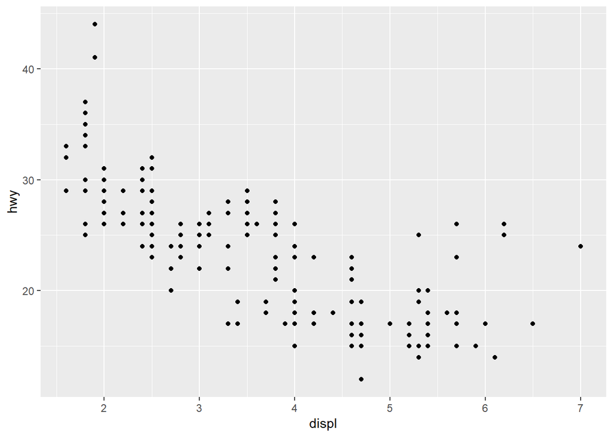

```r
ggplot(data = mpg) +
  geom_point(mapping = aes(x = displ, y = hwy))
```

### 4.1 - Esquema de un ggplot

```r
#ggplot(data = <DATA_FRAME>) +
#  <GEOM_FUNCTION>(mapping = aes(<MAPPINGS>))
```

### 4.2 - ggplot + color + size + alpha

- Color en función de **class**: Tipo de coche
- Tamaño en función de **cty**: Consumo en ciudad
- Transparencia en función de **hwy**: Consumo en autopista

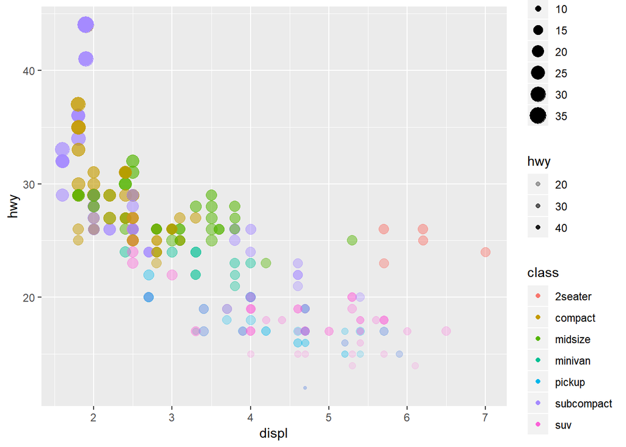

```r
ggplot(data = mpg) +
  geom_point(mapping = aes(x = displ, y = hwy, color = class, size = cty, alpha = hwy))
```

### 4.3 - ggplot + shape

- Formas en función de **class**: Tipo de coche  
  *(En ggplot se pueden representar máximo 6 formas)*

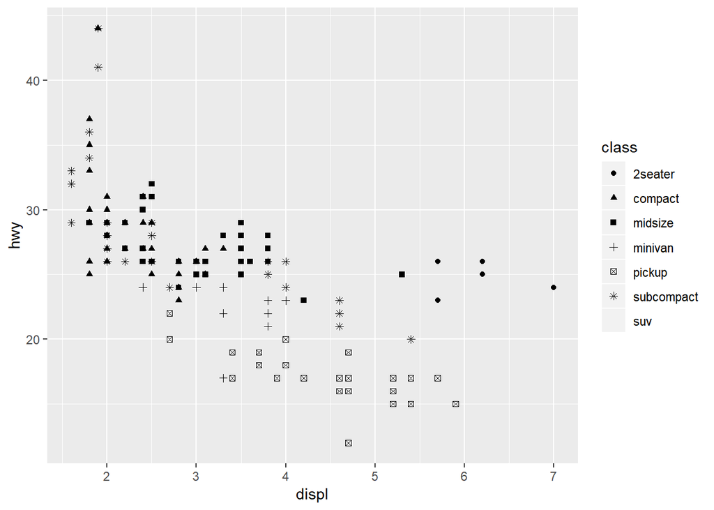

```r
ggplot(data = mpg) +
  geom_point(mapping = aes(x = displ, y = hwy, shape = class))
```

### 4.4 - Las estéticas manuales

Las estéticas se pueden declarar manualmente declarandolas fuera de la estética.

- color = nombre del color en formato string.
- size = tamaño del punto en mm.
- shape = formas del punto de 0 a 25.
- fill = interior

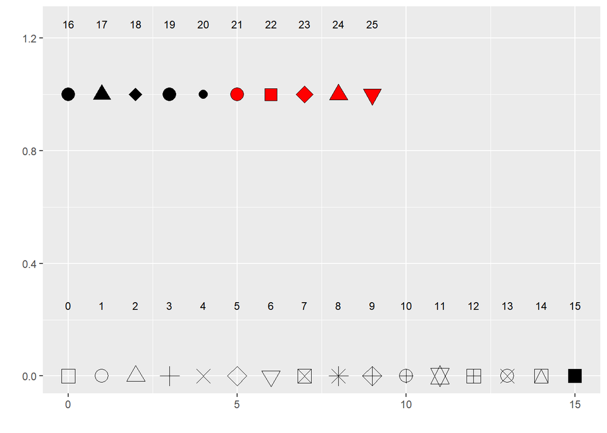

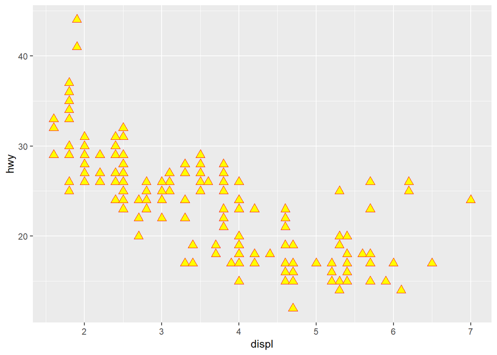

```r
ggplot(data = mpg) +
  geom_point(mapping = aes(x = displ, y = hwy), color = "red", size = 3, shape = 24, fill = "yellow" )
```

### 4.5 - FACETS

#### 4.5.1 - facet_wrap

Segmentar el gráfico en función de una variable.

- Segmentar en función de **class** : Tipo de coche.

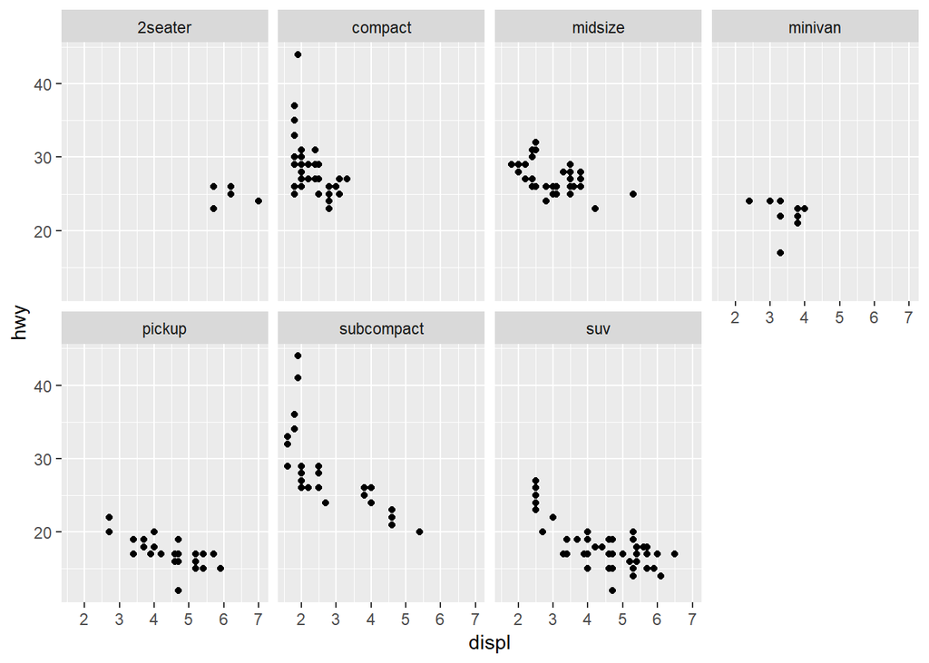

```r
# facet_wrap(~<FORMULA_VARIABLE>) : la variable tiene que ser discreta
ggplot(data = mpg) +
  geom_point(mapping = aes(x = displ, y = hwy)) +
  facet_wrap(~class, nrow = 2)
```

#### 4.5.1 - facet_grid

Segmentar el gráfico en función de dos variables.

- Segmentar en función de **drv**: Tipo de transmisión (eje y) y **class** : Tipo de coche (eje x).

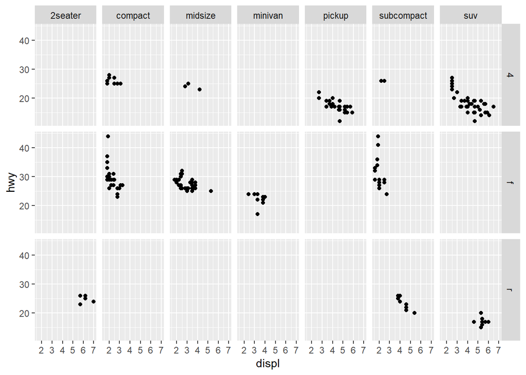

```r
# facet_grid(<FORMULA_VARIABLE>~<FORMULA_VARIABLE>)
ggplot(data = mpg) +
  geom_point(mapping = aes(x = displ, y = hwy)) +
  facet_grid(drv~class)
```

### 4.6 - Diferentes de geometrías

- **linetype**: Cada tipo de transmisión **drv** tiene distinta línea.
- **color**: Cada tipo de transmisión **drv** tiene distinto color. (líneas y puntos)

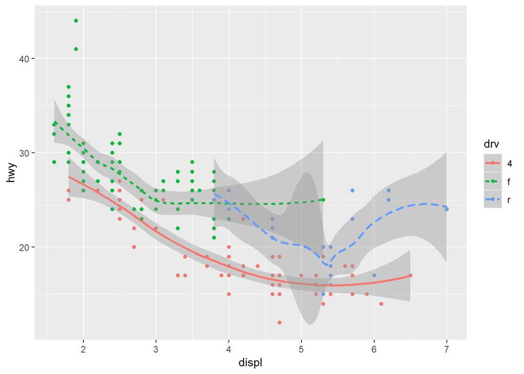

```r
ggplot(data = mpg) +
  geom_point(mapping = aes(x = displ, y = hwy, color = drv)) +
  geom_smooth(mapping = aes(x = displ, y = hwy, linetype = drv, color = drv))
```

- **group**: Realiza la estética agrupada por cada tipo de transmisión **drv**

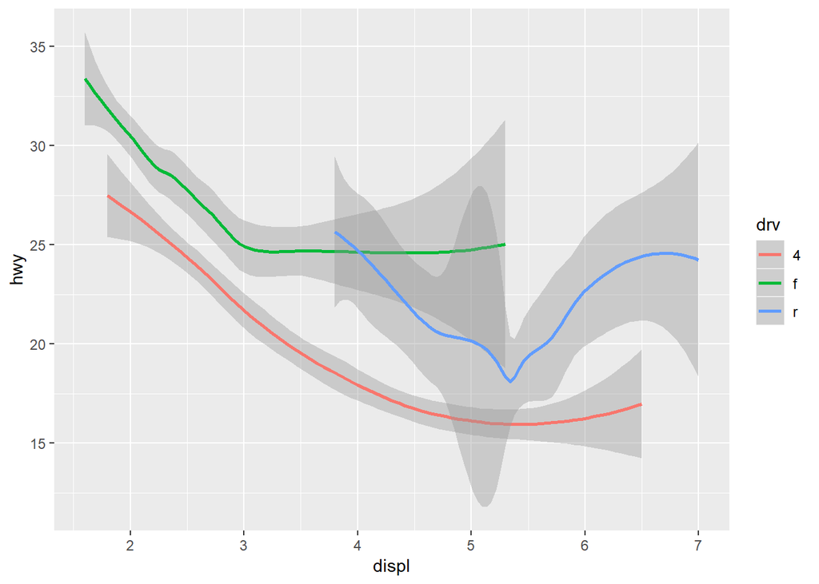

```r
ggplot(data = mpg) +
  geom_smooth(mapping = aes(x = displ, y = hwy, group = drv, color = drv))
```

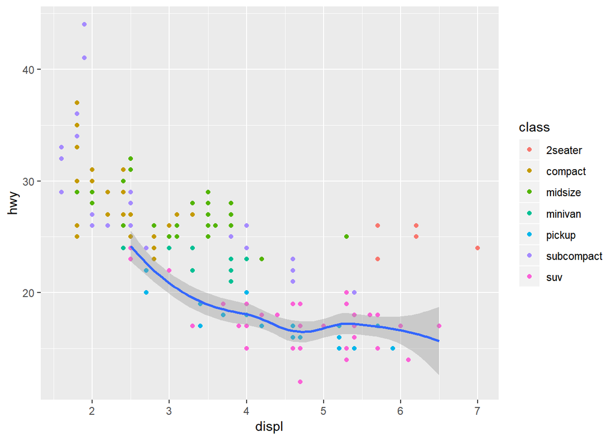

```r
ggplot(data = mpg, mapping = aes(x = displ, y = hwy)) +
  geom_point(mapping = aes(color = class)) +
  geom_smooth(data = filter(mpg, class == "suv"))
```

### 4.7 - Bars Charts

#### 4.7.1 - geom_col

- El tamaño de las barras proviene de los valores. *(usa stat_identity por defecto para dejar el dato como está)*

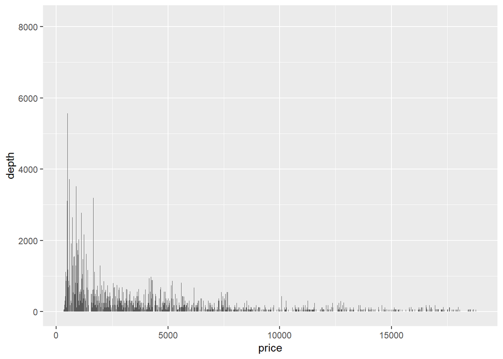

```r
ggplot(data = diamonds) +
  geom_col(mapping = aes(x = price, y = depth))
```

#### 4.7.2 - geom_bars

##### 4.7.2.1 - Contar número de casos

- El tamaño de las barras es prorcional al número de casos de cada grupo.
- Por defecto tiene **stat = “count”**.  
  *(usa stat_count por defecto para contar el número de casos por cada posición)*

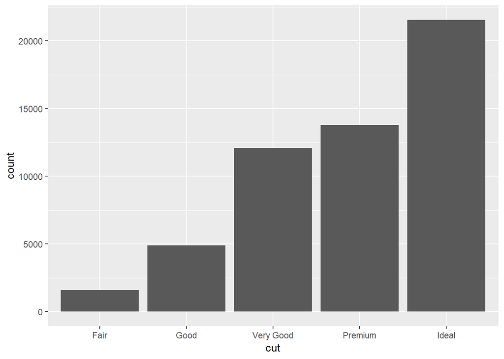

```r
ggplot(data = diamonds) +
  geom_bar(mapping = aes(x = cut))
```

##### 4.7.2.2 - Representar x, y con identity

*Uso de **geom_bar** con **stat = “identity”**.*

**Ejemplo con datos ya contabilizados.**  
* Se crea un dataset con **tribble**

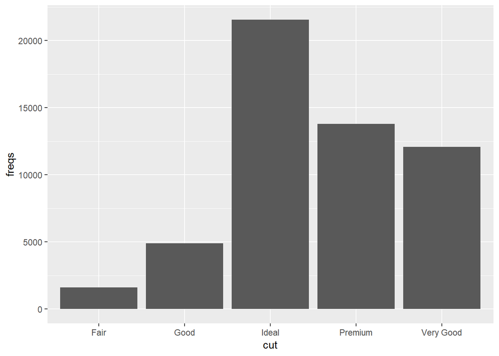

```r
demo_diamonds <- tribble(
  ~cut,       ~freqs,
  "Fair",       1610,
  "Good",       4906,
  "Very Good", 12082,
  "Premium",   13791,
  "Ideal",     21551
)

ggplot(data = demo_diamonds) +
  geom_bar(mapping = aes(x = cut, y = freqs),
           stat = "identity")
```

##### 4.7.2.3 - Representar la proporción de casos

- **..prop.. y group** trabajan juntas.
- **group = 1** es necesario para contar cada registro individualmente.

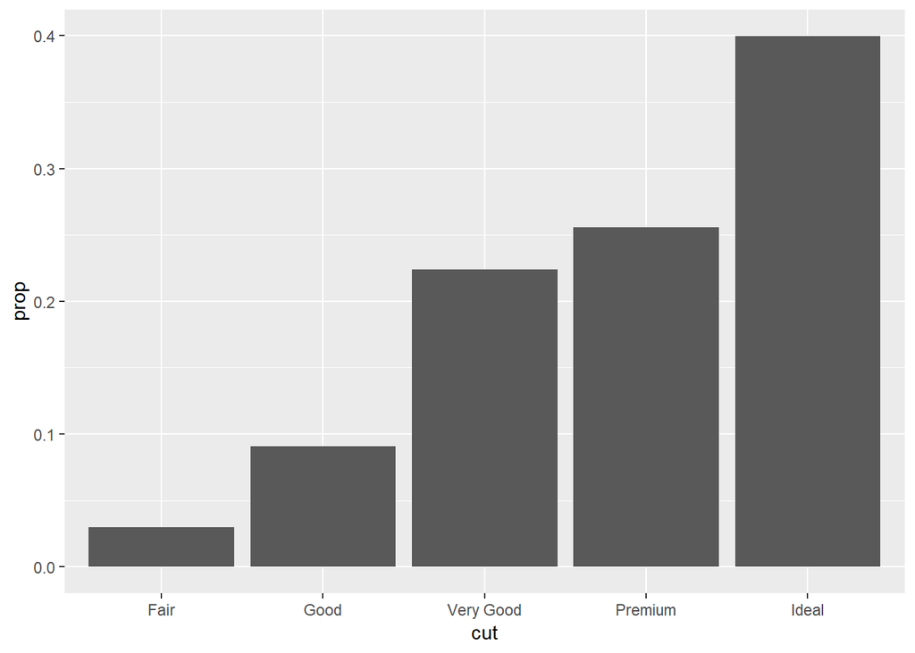

```r
ggplot(data = diamonds) +
  geom_bar(mapping = aes(x = cut, y = ..prop.., group = 1))
```

##### 4.7.2.4 - Diagrama de barras apilado

- Se representa el corte **cut**
- Se colorea por la claridad, **clarity**, del diamante

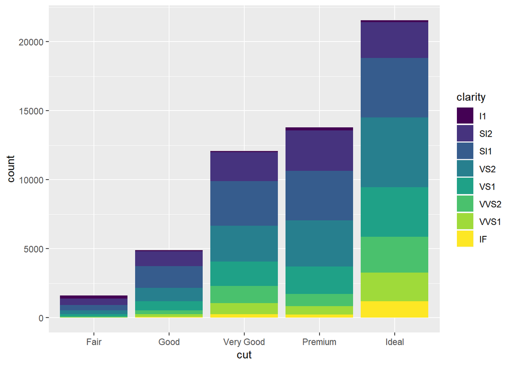

```r
ggplot(data = diamonds) +
  geom_bar(mapping = aes(x = cut, fill = clarity))
```

##### 4.7.2.5 - Control de el apilado o stack

- Control mediante **position** “fill”, “dodge”.

###### 4.7.2.5.1 - position = “fill”

- Interesante para evaluar proporciones.

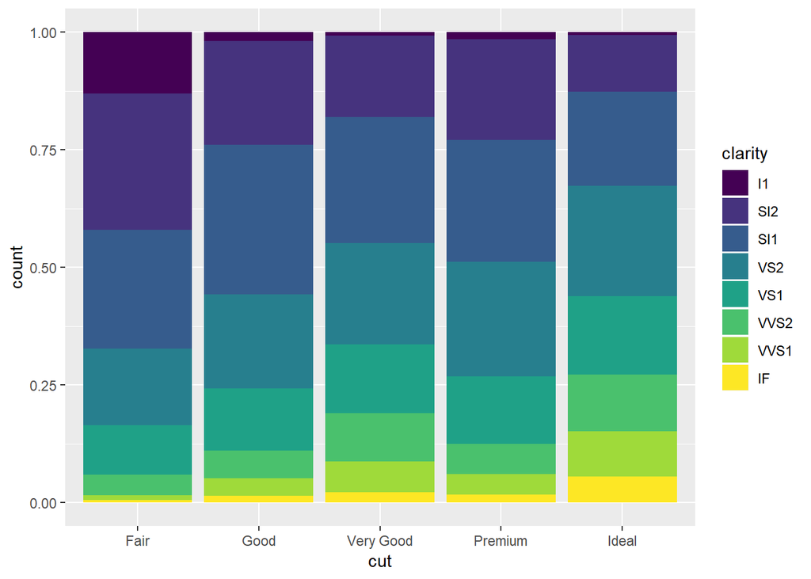

```r
ggplot(data = diamonds, mapping = aes( x = cut, fill = clarity)) +
  geom_bar( position = "fill")
```

###### 4.7.2.5.2 - position = “dodge”

- Las barras una al lado de las otras.

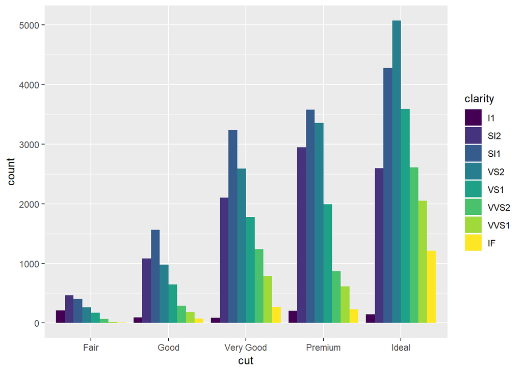

```r
ggplot(data = diamonds, mapping = aes( x = cut, fill = clarity)) +
  geom_bar( position = "dodge")
```

#### 4.7.3 - Solución para el Overplotting

- Uso de **position = “jitter”**
- Añade ruido aleatorio para evitar la superposición.

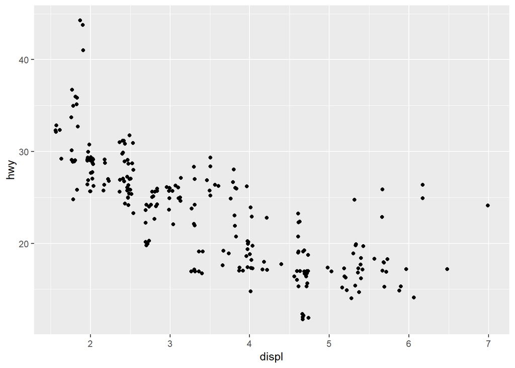

```r
ggplot(data = mpg, mapping = aes(x = displ, y = hwy)) +
  geom_point(position = "jitter")
```

#### 4.7.4 - Sistema de coordenadas (rotar el gráfico)

- **coord_flip()** intercambia x por y

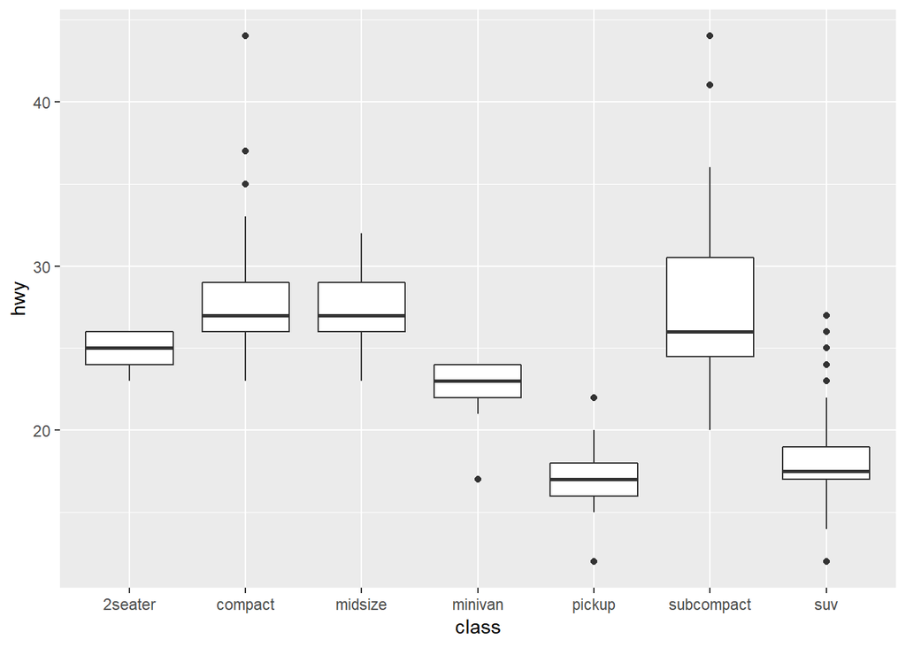

```r
ggplot(data = mpg, mapping = aes(x = class, y = hwy)) +
  geom_boxplot()
```

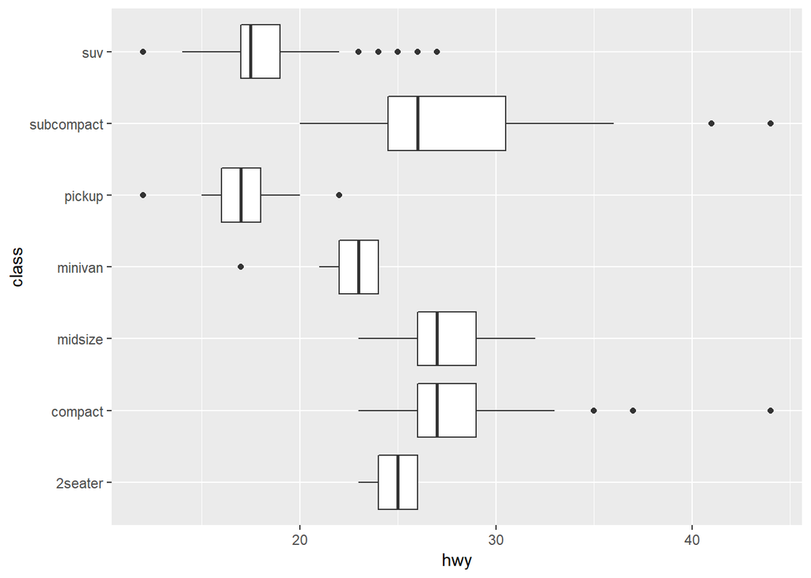

```r
ggplot(data = mpg, mapping = aes(x = class, y = hwy)) +
  geom_boxplot() +
  coord_flip()
```

#### 4.7.5 - Coordenadas Polares (tela araña)

- **coord_polar()**

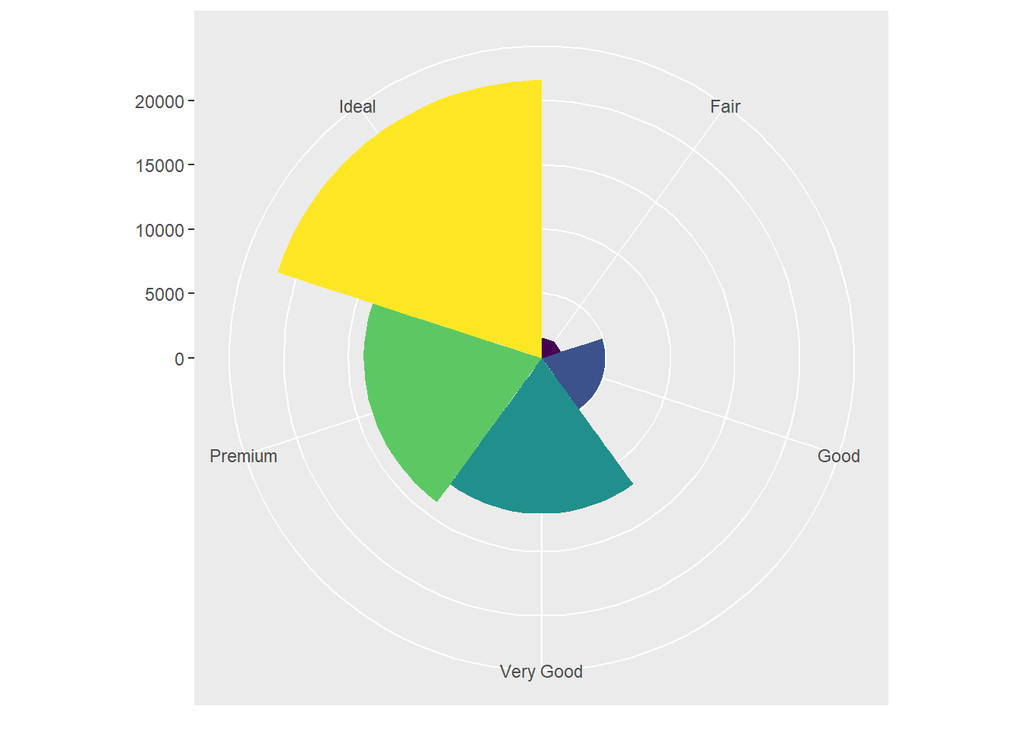

```r
ggplot(data = diamonds) +
  geom_bar(mapping = aes(x= cut, fill = cut),
           show.legend = F,
           width = 1) +
  theme(aspect.ratio = 1) +
  labs(x = NULL, y = NULL) +
  coord_polar()
```

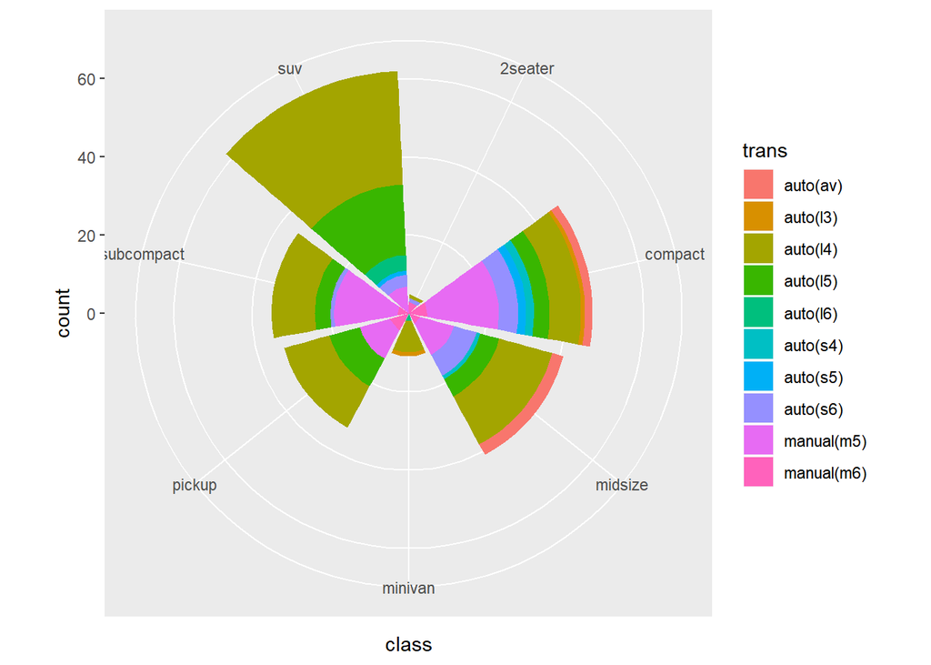

```r
ggplot(data = mpg, mapping = aes(x = class, fill = trans)) +
  geom_bar() +
  coord_polar()
```